# SH_02_COM_SUP_NUM_ACT_PROG

Community support - number of activities and programs · Number report

## Overview

**Description**

Number of activities or programs

**Table**

`SH-P02-T00-FAP-COMMUNITY-BENEFIT-POLICY` (one )

**Location code**

`SCHED-H-PART-02-LINE-03-COL-A`

**Family**

`SCHED-H-PART-02-LINE-03-COL-A`

**Data type**

numeric (xsd: IntegerNNType, )

**Scope**

PC

**Status**

unreviewed

3

xpaths mapped (2 observed)

4,471

filings with a value

2009–2024

tax years observed

1

open flags (0 errors)

## Flags

| Severity | Flag | Xpath | Detail |
| --- | --- | --- | --- |
| ⓘ info | `UNOBSERVED` | IRS990ScheduleH/Form990ScheduleHPartII/CommunitySupport/NumberOfActivitiesOrPrograms | never observed in TY2009-2024 filings |

## Xpaths

All mapped xpaths (under /Return/ReturnData or /Return/ReturnHeader), oldest first. Charts label each series by its xpath.

| Xpath | Form | Chart label | First year | Last year | Versions | Filings | Repeats in |
| --- | --- | --- | --- | --- | --- | --- | --- |
| IRS990ScheduleH/CommunitySupport/NumberOfActivitiesOrPrograms | Sched H | …90ScheduleH/CommunitySupport/NumberOfActivitiesOrPrograms | 2009 | 2012 | 16 | 1,231 | 0.0% |
| IRS990ScheduleH/CommunitySupportGrp/ActivitiesOrProgramsCnt | Sched H | same | 2013 | 2024 | 34 | 3,240 | 0.0% |
| IRS990ScheduleH/Form990ScheduleHPartII/CommunitySupport/NumberOfActivitiesOrPrograms | Sched H | …duleHPartII/CommunitySupport/NumberOfActivitiesOrPrograms |  |  |  | 0 |  |

## Coverage

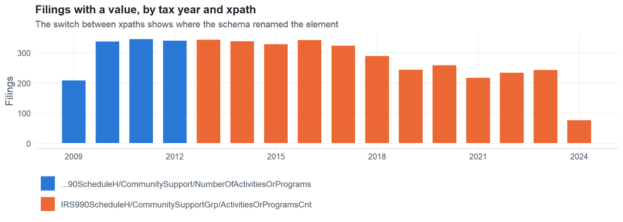

**Table view**

Table view: filings by tax year and series

| Tax year | …90ScheduleH/CommunitySupport/NumberOfActivitiesOrPrograms | IRS990ScheduleH/CommunitySupportGrp/ActivitiesOrProgramsCnt |
| --- | --- | --- |
| 2009 | 209 | 0 |
| 2010 | 337 | 0 |
| 2011 | 345 | 0 |
| 2012 | 340 | 0 |
| 2013 | 0 | 343 |
| 2014 | 0 | 338 |
| 2015 | 0 | 329 |
| 2016 | 0 | 342 |
| 2017 | 0 | 324 |
| 2018 | 0 | 289 |
| 2019 | 0 | 244 |
| 2020 | 0 | 259 |
| 2021 | 0 | 218 |
| 2022 | 0 | 234 |
| 2023 | 0 | 243 |
| 2024 | 0 | 77 |

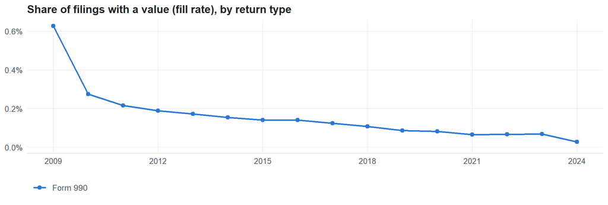

**Table view**

Table view: fill rate

| Tax year | Return type | Filings | All filings | Fill rate |
| --- | --- | --- | --- | --- |
| 2009 | Form 990 | 209 | 33,311 | 0.63% |
| 2010 | Form 990 | 337 | 123,025 | 0.27% |
| 2011 | Form 990 | 345 | 159,504 | 0.22% |
| 2012 | Form 990 | 340 | 179,688 | 0.19% |
| 2013 | Form 990 | 343 | 198,855 | 0.17% |
| 2014 | Form 990 | 338 | 218,619 | 0.15% |
| 2015 | Form 990 | 329 | 233,519 | 0.14% |
| 2016 | Form 990 | 342 | 243,903 | 0.14% |
| 2017 | Form 990 | 324 | 261,612 | 0.12% |
| 2018 | Form 990 | 289 | 271,442 | 0.11% |
| 2019 | Form 990 | 244 | 283,694 | 0.09% |
| 2020 | Form 990 | 259 | 320,342 | 0.08% |
| 2021 | Form 990 | 218 | 336,480 | 0.06% |
| 2022 | Form 990 | 234 | 349,055 | 0.07% |
| 2023 | Form 990 | 243 | 354,768 | 0.07% |
| 2024 | Form 990 | 77 | 277,298 | 0.03% |

## Values

[output not shown]

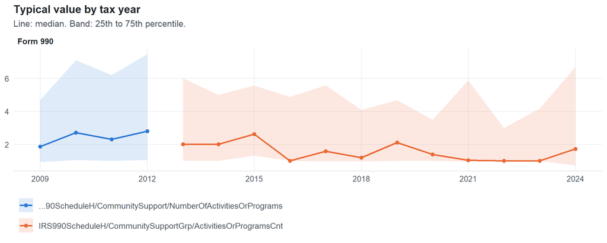

**Table view**

Table view: quartiles by tax year

| Series | Return | Tax year | Filings | P25 | Median | P75 |
| --- | --- | --- | --- | --- | --- | --- |
| …90ScheduleH/CommunitySupport/NumberOfActivitiesOrPrograms | 990 | 2009 | 209 | 0.92 | 1.86 | 4.69 |
| …90ScheduleH/CommunitySupport/NumberOfActivitiesOrPrograms | 990 | 2010 | 337 | 1.05 | 2.71 | 7.09 |
| …90ScheduleH/CommunitySupport/NumberOfActivitiesOrPrograms | 990 | 2011 | 345 | 1 | 2.31 | 6.19 |
| …90ScheduleH/CommunitySupport/NumberOfActivitiesOrPrograms | 990 | 2012 | 340 | 1.05 | 2.81 | 7.48 |
| IRS990ScheduleH/CommunitySupportGrp/ActivitiesOrProgramsCnt | 990 | 2013 | 343 | 1 | 2 | 6 |
| IRS990ScheduleH/CommunitySupportGrp/ActivitiesOrProgramsCnt | 990 | 2014 | 338 | 1 | 2 | 5 |
| IRS990ScheduleH/CommunitySupportGrp/ActivitiesOrProgramsCnt | 990 | 2015 | 329 | 1.32 | 2.62 | 5.57 |
| IRS990ScheduleH/CommunitySupportGrp/ActivitiesOrProgramsCnt | 990 | 2016 | 342 | 1 | 1 | 4.88 |
| IRS990ScheduleH/CommunitySupportGrp/ActivitiesOrProgramsCnt | 990 | 2017 | 324 | 0.96 | 1.59 | 5.59 |
| IRS990ScheduleH/CommunitySupportGrp/ActivitiesOrProgramsCnt | 990 | 2018 | 289 | 0.97 | 1.20 | 4.08 |
| IRS990ScheduleH/CommunitySupportGrp/ActivitiesOrProgramsCnt | 990 | 2019 | 244 | 1 | 2.12 | 4.68 |
| IRS990ScheduleH/CommunitySupportGrp/ActivitiesOrProgramsCnt | 990 | 2020 | 259 | 1 | 1.39 | 3.49 |
| IRS990ScheduleH/CommunitySupportGrp/ActivitiesOrProgramsCnt | 990 | 2021 | 218 | 0.96 | 1.04 | 5.88 |
| IRS990ScheduleH/CommunitySupportGrp/ActivitiesOrProgramsCnt | 990 | 2022 | 234 | 1 | 1 | 3 |
| IRS990ScheduleH/CommunitySupportGrp/ActivitiesOrProgramsCnt | 990 | 2023 | 243 | 1.00 | 1.00 | 4.17 |
| IRS990ScheduleH/CommunitySupportGrp/ActivitiesOrProgramsCnt | 990 | 2024 | 77 | 0.71 | 1.73 | 6.70 |

Summary by xpath and return type (all years)

| Series | Return | Filings | % numeric | % zero | % negative | Median (typical year) | P99 (typical year) |
| --- | --- | --- | --- | --- | --- | --- | --- |
| …90ScheduleH/CommunitySupport/NumberOfActivitiesOrPrograms | 990 | 1,231 | 100 | 4.14 | 0 | 2 | 53 |
| IRS990ScheduleH/CommunitySupportGrp/ActivitiesOrProgramsCnt | 990 | 3,240 | 100 | 8.92 | 0 | 1 | 168 |

Scale of each xpath

| Series | P99 (typical year) | Implied scale |
| --- | --- | --- |
| …90ScheduleH/CommunitySupport/NumberOfActivitiesOrPrograms | 53 | percent or small count |
| IRS990ScheduleH/CommunitySupportGrp/ActivitiesOrProgramsCnt | 168 | large count or amount |

## Examples

| Tax year | Return | Xpath | Organization | Value | Source |
| --- | --- | --- | --- | --- | --- |
| 2024 | 990 | IRS990ScheduleH/CommunitySupportGrp/ActivitiesOrProgramsCnt | BLYTHEDALE CHILDREN’S HOSPITAL | 1 | [XML](https://gt990datalake-rawdata.s3.amazonaws.com/EfileData/XmlFiles/202523219349322732_public.xml) |
| 2023 | 990 | IRS990ScheduleH/CommunitySupportGrp/ActivitiesOrProgramsCnt | ARH TUG VALLEY HEALTH SERVICES INC | 14 | [XML](https://gt990datalake-rawdata.s3.amazonaws.com/EfileData/XmlFiles/202511349349306946_public.xml) |
| 2022 | 990 | IRS990ScheduleH/CommunitySupportGrp/ActivitiesOrProgramsCnt | Central Valley Medical Center | 4 | [XML](https://gt990datalake-rawdata.s3.amazonaws.com/EfileData/XmlFiles/202421169349301862_public.xml) |
| 2021 | 990 | IRS990ScheduleH/CommunitySupportGrp/ActivitiesOrProgramsCnt | Jefferson Hospital Association Inc | 31 | [XML](https://gt990datalake-rawdata.s3.amazonaws.com/EfileData/XmlFiles/202311329349307796_public.xml) |
| 2020 | 990 | IRS990ScheduleH/CommunitySupportGrp/ActivitiesOrProgramsCnt | NORTHEAST GEORGIA HEALTH SYSTEM INC | 1 | [XML](https://gt990datalake-rawdata.s3.amazonaws.com/EfileData/XmlFiles/202212249349301571_public.xml) |
| 2019 | 990 | IRS990ScheduleH/CommunitySupportGrp/ActivitiesOrProgramsCnt | CENTRASTATE MEDICAL CENTER INC | 2 | [XML](https://gt990datalake-rawdata.s3.amazonaws.com/EfileData/XmlFiles/202003079349301655_public.xml) |
| 2018 | 990 | IRS990ScheduleH/CommunitySupportGrp/ActivitiesOrProgramsCnt | COMMUNITY HOSPITAL OF THE MONTEREY | 5 | [XML](https://gt990datalake-rawdata.s3.amazonaws.com/EfileData/XmlFiles/201943189349314499_public.xml) |
| 2017 | 990 | IRS990ScheduleH/CommunitySupportGrp/ActivitiesOrProgramsCnt | Saint Elizabeth Regional Medical Center | 0 | [XML](https://gt990datalake-rawdata.s3.amazonaws.com/EfileData/XmlFiles/202141889339303314_public.xml) |
| 2016 | 990 | IRS990ScheduleH/CommunitySupportGrp/ActivitiesOrProgramsCnt | St Francis Hospital Inc | 6 | [XML](https://gt990datalake-rawdata.s3.amazonaws.com/EfileData/XmlFiles/201841849349300214_public.xml) |
| 2015 | 990 | IRS990ScheduleH/CommunitySupportGrp/ActivitiesOrProgramsCnt | Alegent Health-Bergan Mercy Health System | 1 | [XML](https://gt990datalake-rawdata.s3.amazonaws.com/EfileData/XmlFiles/201741319349304814_public.xml) |
| 2014 | 990 | IRS990ScheduleH/CommunitySupportGrp/ActivitiesOrProgramsCnt | HIAWATHA HOSPITAL ASSOCIATION INC | 1 | [XML](https://gt990datalake-rawdata.s3.amazonaws.com/EfileData/XmlFiles/201513209349304046_public.xml) |
| 2013 | 990 | IRS990ScheduleH/CommunitySupportGrp/ActivitiesOrProgramsCnt | Alexian Brothers Behavioral Health Hospital | 1 | [XML](https://gt990datalake-rawdata.s3.amazonaws.com/EfileData/XmlFiles/201501279349301430_public.xml) |

## Reviewer checklist

- The definition matches the form line and instructions for every xpath’s schema years.
- Every xpath pooled here measures the same thing on the 990 and 990-EZ (close enough for analysis).
- The coverage chart has no unexplained gaps or jumps between tax years.
- Each open flag is fixed, or accepted with a note in validation_log.csv.
- Counts are whole numbers and plausible (e.g. employees, volunteers, voting members).
- Ratios and percentages use one scale (0-1 or 0-100) across all xpaths and years.
- Units match the form line (hours per week, number of states, percent of support).

Record the review as a row in `inst/extdata/src/validation_log.csv` (variable_name, reviewer, date, status, note). Evidence built 2026-09-23 17:09:04 MST from the ef2 DuckDB builds (tax years 2009–2024).